# Exam stats

2021-06-27

# Exercise 1

1. Stwórz wektor w1 zawierający 100 obserwacji pochodzących z rozkładu normalnego o średniej 5 i odchyleniu standardowym 1.5 (w1 <- rnorm(100, 5, 1.5))

```r
w1 <- rnorm(100, 5, 1.5)
```

```r
above_1.5_sd = length(w1[w1 > mean(w1) + sd(w1) * 1.5])
under_1.5_sd = length(w1[w1 < mean(w1) - sd(w1) * 1.5])
above_1.5_sd + under_1.5_sd
```

```
[1] 11
```

2. Wybierz z wektora w1 elementy o wartościach większych od wartości średniej

```r
w1[w1 > mean(w1)]
```

```
 [1] 6.160426 5.177716 6.680128 6.912690 5.827465 6.603074 5.351591 5.053591
 [9] 6.604104 5.705120 5.851783 5.977478 6.567698 6.236496 5.710022 6.127576
[17] 6.127742 6.413604 5.526883 5.961079 5.782145 5.133857 5.808797 6.261559
[25] 5.302187 7.029759 6.820497 5.616092 5.567212 6.327369 5.950067 5.546353
[33] 6.634630 5.126463 7.007304 7.060096 7.038113 6.772190 5.437280 6.766768
[41] 5.616344 5.388003 5.685348 5.789229 5.594353 7.582334 5.314018 6.603774
```

# Exercise 2

2. Utwórz macierz przy pomocy polecenia m2 <- matrix(sample(1:9), 3, 3, byrow = TRUE)

```r
m2 <- matrix(sample(1:9), 3, 3, byrow = TRUE)
```

1. Wyznacz sumę elementów drugiej kolumny

```r
sum(m2[, 2])
```

```
[1] 12
```

2. Wyznacz sumę elementów trzeciego wiersza

```r
sum(m2[3, ])
```

```
[1] 16
```

# Exercise 3

1. Wyznacz podstawowe statystyki opisowe dla zmiennych numerycznych z ramki danych (iris)

```r
data(iris)
attach(iris)
summary(iris[1:4])
```

```
  Sepal.Length    Sepal.Width     Petal.Length    Petal.Width
 Min.   :4.300   Min.   :2.000   Min.   :1.000   Min.   :0.100
 1st Qu.:5.100   1st Qu.:2.800   1st Qu.:1.600   1st Qu.:0.300
 Median :5.800   Median :3.000   Median :4.350   Median :1.300
 Mean   :5.843   Mean   :3.057   Mean   :3.758   Mean   :1.199
 3rd Qu.:6.400   3rd Qu.:3.300   3rd Qu.:5.100   3rd Qu.:1.800
 Max.   :7.900   Max.   :4.400   Max.   :6.900   Max.   :2.500
```

decyle dla każdej zmiennej numerycznej w dataset „iris":

```r
for (i in colnames(iris[1:4])) {
    print(i)
    print((quantile(iris[[i]], seq(0.1, 1, 0.1))))
}
```

```
[1] "Sepal.Length"
 10%  20%  30%  40%  50%  60%  70%  80%  90% 100%
4.80 5.00 5.27 5.60 5.80 6.10 6.30 6.52 6.90 7.90
[1] "Sepal.Width"
 10%  20%  30%  40%  50%  60%  70%  80%  90% 100%
2.50 2.70 2.80 3.00 3.00 3.10 3.20 3.40 3.61 4.40
[1] "Petal.Length"
 10%  20%  30%  40%  50%  60%  70%  80%  90% 100%
1.40 1.50 1.70 3.90 4.35 4.64 5.00 5.32 5.80 6.90
[1] "Petal.Width"
 10%  20%  30%  40%  50%  60%  70%  80%  90% 100%
0.20 0.20 0.40 1.16 1.30 1.50 1.80 1.90 2.20 2.50
```

1. Wyznacz podstawowe statystyki opisowe dla zmiennych numerycznych, w grupie setosa

```r
iris_setosa <- subset(iris, Species == "setosa")
summary(iris_setosa[1:4])
```

```
  Sepal.Length    Sepal.Width     Petal.Length    Petal.Width
 Min.   :4.300   Min.   :2.300   Min.   :1.000   Min.   :0.100
 1st Qu.:4.800   1st Qu.:3.200   1st Qu.:1.400   1st Qu.:0.200
 Median :5.000   Median :3.400   Median :1.500   Median :0.200
 Mean   :5.006   Mean   :3.428   Mean   :1.462   Mean   :0.246
 3rd Qu.:5.200   3rd Qu.:3.675   3rd Qu.:1.575   3rd Qu.:0.300
 Max.   :5.800   Max.   :4.400   Max.   :1.900   Max.   :0.600
```

decyle dla każdej zmiennej numerycznej w zbiorze danych „iris_setosa"

```r
for (i in colnames(iris_setosa[1:4])) {
    print(i)
    print((quantile(iris_setosa[[i]], seq(0.1, 1, 0.1))))
}
```

```
[1] "Sepal.Length"
 10%  20%  30%  40%  50%  60%  70%  80%  90% 100%
4.59 4.70 4.80 4.96 5.00 5.10 5.10 5.32 5.41 5.80
[1] "Sepal.Width"
 10%  20%  30%  40%  50%  60%  70%  80%  90% 100%
3.00 3.10 3.20 3.40 3.40 3.50 3.60 3.72 3.90 4.40
[1] "Petal.Length"
 10%  20%  30%  40%  50%  60%  70%  80%  90% 100%
 1.3  1.3  1.4  1.4  1.5  1.5  1.5  1.6  1.7  1.9
[1] "Petal.Width"
 10%  20%  30%  40%  50%  60%  70%  80%  90% 100%
0.19 0.20 0.20 0.20 0.20 0.20 0.30 0.30 0.40 0.60
```

2. Oblicz średnią arytmetyczną (sd, wariancję) parametru X w grupie versicolor/setosa/virginica;

*setosa:*

```r
iris_setosa <- subset(iris, Species == "setosa")
for (i in colnames(iris_setosa[1:4])) {
    print(i)
    print((mean(iris_setosa[[i]])))  # arithmetic mean
    print((var(iris_setosa[[i]])))  # variance
    print((sd(iris_setosa[[i]])))  # sd
}
```

```
[1] "Sepal.Length"
[1] 5.006
[1] 0.124249
[1] 0.3524897
[1] "Sepal.Width"
[1] 3.428
[1] 0.1436898
[1] 0.3790644
[1] "Petal.Length"
[1] 1.462
[1] 0.03015918
[1] 0.173664
[1] "Petal.Width"
[1] 0.246
[1] 0.01110612
[1] 0.1053856
```

*versicolor:*

```r
iris_versicolor <- subset(iris, Species == "versicolor")
for (i in colnames(iris_versicolor[1:4])) {
    print(i)
    print((mean(iris_versicolor[[i]])))  # arithmetic mean
    print((var(iris_versicolor[[i]])))  # variance
    print((sd(iris_versicolor[[i]])))  # sd
}
```

```
[1] "Sepal.Length"
[1] 5.936
[1] 0.2664327
[1] 0.5161711
[1] "Sepal.Width"
[1] 2.77
[1] 0.09846939
[1] 0.3137983
[1] "Petal.Length"
[1] 4.26
[1] 0.2208163
[1] 0.469911
[1] "Petal.Width"
[1] 1.326
[1] 0.03910612
[1] 0.1977527
```

*virginica:*

```r
iris_virginica <- subset(iris, Species == "virginica")
for (i in colnames(iris_virginica[1:4])) {
    print(i)
    print((mean(iris_virginica[[i]])))  # arithmetic mean
    print((var(iris_virginica[[i]])))  # variance
    print((sd(iris_virginica[[i]])))  # sd
}
```

```
[1] "Sepal.Length"
[1] 6.588
[1] 0.4043429
[1] 0.6358796
[1] "Sepal.Width"
[1] 2.974
[1] 0.1040041
[1] 0.3224966
[1] "Petal.Length"
[1] 5.552
[1] 0.3045878
[1] 0.5518947
[1] "Petal.Width"
[1] 2.026
[1] 0.07543265
[1] 0.2746501
```

3. Stwórz histogram dla parametru numerycznego hist(iris_setosa$Sepal.Length)

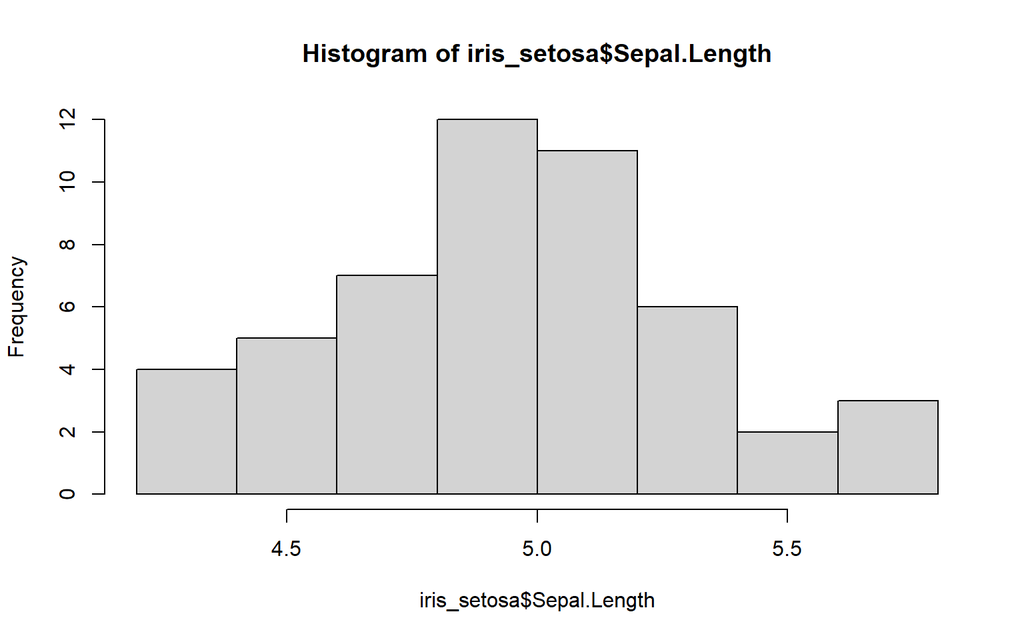

```r
hist(iris_setosa$Sepal.Length)
```

4. Stwórz wykres skrzynkowy dla parametru numerycznego dla dwóch (trzech) grup (boxplot(Sepal.Length~Species, iris) # 3 grupy

*3 grupy:*

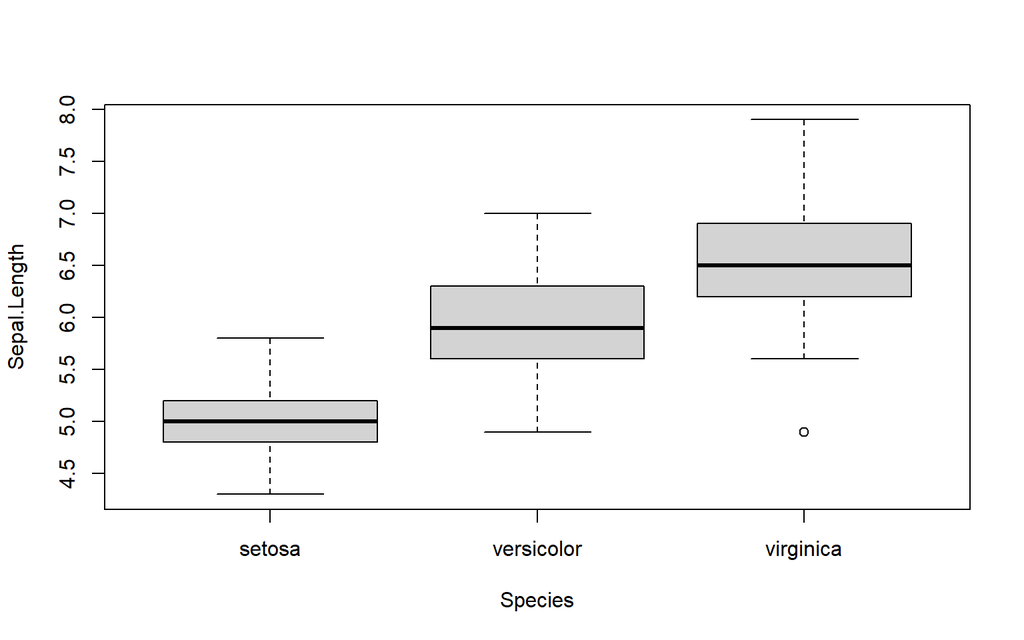

```r
boxplot(Sepal.Length ~ Species, iris)
```

*2 grupy:*

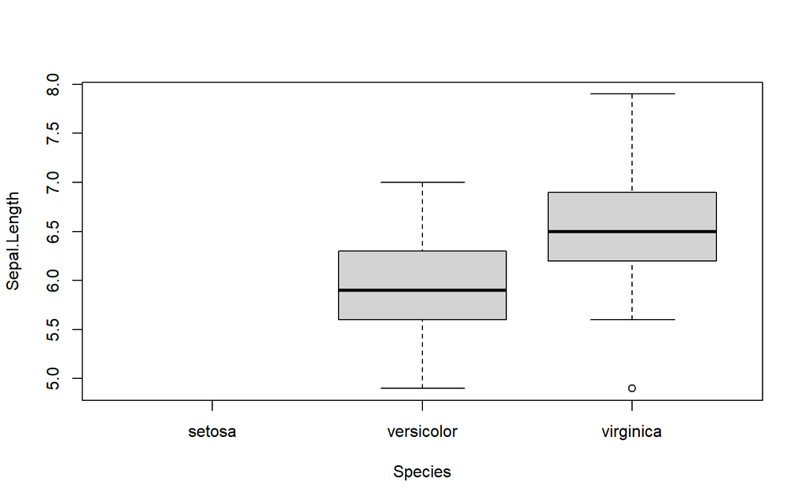

```r
boxplot(Sepal.Length ~ Species, subset(iris, Species != "setosa"))
```

5. Stwórz wykres punktowy dla parametrów numerycznych (X i Y), wyznacz współczynnik korelacji Pearsona dla tych parametrów (cor()) cor(iris_setosa$Sepal.Length, iris_setosa$Sepal.Width)

*wykres punktowy dla parametrów numerycznych (X i Y):*

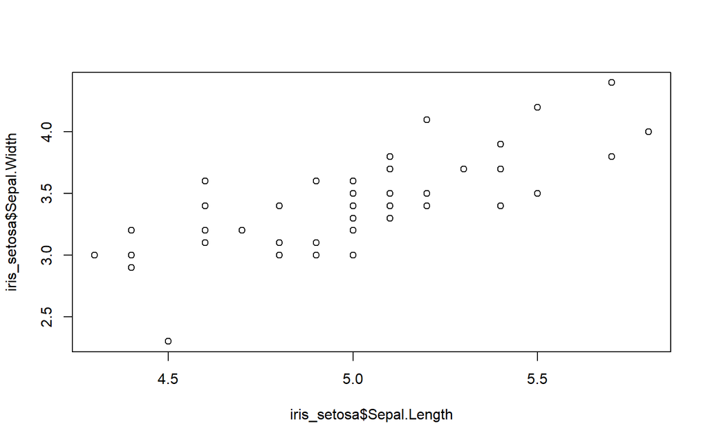

```r
plot(iris_setosa$Sepal.Length, iris_setosa$Sepal.Width)
```

*Pearson correlation coefficient*

```r
cor(iris_setosa$Sepal.Length, iris_setosa$Sepal.Width)
```

```
[1] 0.7425467
```

# Exercise 4

4. Wykonaj test t dla danych niesparowanych, sprawdź założenia o normalności rozkładu i równości wariancji pomiędzy grupami (dane iris)

*Normality tests for the variable Sepal.Length:* The null hypothesis of Shapiro’s test is that the population is distributed normally.

*Shapiro’s test for iris_setosa:*

```r
shapiro.test(iris_setosa$Sepal.Length)
```

```
    Shapiro-Wilk normality test

data:  iris_setosa$Sepal.Length
W = 0.9777, p-value = 0.4595
```

We can see that the p-value = 0.4595 (higher than 0.05) therefore we accept the null hypothesis that the data is normally distributed

*Shapiro’s test for iris_versicolor:*

```r
shapiro.test(iris_versicolor$Sepal.Length)
```

```
    Shapiro-Wilk normality test

data:  iris_versicolor$Sepal.Length
W = 0.97784, p-value = 0.4647
```

We can see that the p-value = 0.4647 (higher than 0.05) therefore we accept the null hypothesis that the data is normally distributed

As both samples are have a normal distribution, we can perform a t.test

*t-test:* The null hypothesis is that the two means are equal, and the alternative is that they are not.

```r
t.test(iris_setosa$Sepal.Length, iris_versicolor$Sepal.Length)
```

```
    Welch Two Sample t-test

data:  iris_setosa$Sepal.Length and iris_versicolor$Sepal.Length
t = -10.521, df = 86.538, p-value < 2.2e-16
alternative hypothesis: true difference in means is not equal to 0
95 percent confidence interval:
 -1.1057074 -0.7542926
sample estimates:
mean of x mean of y
    5.006     5.936
```

The p-value < 2.2e-16 is smaller than 0.05 therefore we reject the null hypothesis and we can conclude with 95% of confidence that the mean of the data samples differ from each other.

# Exercise 5

5. Wykonaj test t dla danych sparowanych (ChickWeight, Time 0 i 2)

we subset the data:

```r
ch_time0 <- subset(ChickWeight, Time == 0)
ch_time2 <- subset(ChickWeight, Time == 2)
```

*Shapiro’s test for ch_time0:*

```r
shapiro.test(ch_time0$weight)
```

```
    Shapiro-Wilk normality test

data:  ch_time0$weight
W = 0.88961, p-value = 0.0002219
```

p-value = 0.0002219 is less than 0.05 then we reject the null hypothesis and assume that the data doesn’t follow a normal (gaussian) distribution

*Shapiro’s test for ch_time2:*

```r
shapiro.test(ch_time2$weight)
```

```
    Shapiro-Wilk normality test

data:  ch_time2$weight
W = 0.8729, p-value = 6.859e-05
```

p-value = 6.859e-05 is less than 0.05 then we reject the null hypothesis and assume that the data doesn’t follow a normal (gaussian) distribution

The common assumptions made when doing a t-test include the following: - the two groups are paired. - No significant outliers in the difference between the two related groups - *Normality. the difference of pairs follow a normal distribution.*

Theoretically we couldn’t perform the t-test since the data *is not* normally distributed, and estimates will be biased. However the prof is asking for that…

```r
t.test(ch_time0$weight, ch_time2$weight, paired = TRUE)
```

```
    Paired t-test

data:  ch_time0$weight and ch_time2$weight
t = -15.907, df = 49, p-value < 2.2e-16
alternative hypothesis: true difference in means is not equal to 0
95 percent confidence interval:
 -9.190877 -7.129123
sample estimates:
mean of the differences
                  -8.16
```

The p-value < 2.2e-16 is less than significance level alpha = 0.05 therefore we reject the null hypothesis and conclude that the average weight of the chicks in time 0 is significantly different from the average weight in time 2.

# Exercise 6

6. Wykonaj analizę wariancji jednoczynnikową (PlantGrowth)

ANOVA, or Analysis of Variance, is a commonly used approach to testing a hypothesis when dealing with two or more groups. One-way ANOVA, which is what will be explored in this post, **can be considered an extension of the t-test** when more than two groups are being tested. The factor, or categorical variable, is often referred to as the ‘treatment’ in the ANOVA setting. ANOVA involves partitioning the data’s total variation into variation between and within groups. This procedure is thus known as Analysis of Variance as sources of variation are examined separately.

*The data is still assumed to be normally distributed*

The hypothesis can be defined formally as:

$HO:μ1=μ2=⋯=μk$$

HA: Not all population means are equal

Consider an experiment designed to test plant yields from a control and two different treatments. The returns of each group are collected, and the dry weights of the plants are measured. Is there a difference in the means of the treatments?

There is no reason to assume there is a difference between the control and the two treatments so the hypothesis for this example can, therefore, be stated as:

$H0:μc=μt1=μt2$  
HA: At least one mean between the control and the two treatments is not equal.

First, start by loading the packages that will be needed to analyze the data as well as the dataset. The `PlantGrowth` dataset is available with base R.

```r
aov_res <- aov(weight ~ group, PlantGrowth)
summary(aov_res)
```

```
            Df Sum Sq Mean Sq F value Pr(>F)
group        2  3.766  1.8832   4.846 0.0159 *
Residuals   27 10.492  0.3886
---
Signif. codes:  0 '***' 0.001 '**' 0.01 '*' 0.05 '.' 0.1 ' ' 1
```

As we know that there are differences. We want to know where these differences are. TukeyHSD is a common method to determine where these differences exist

```r
tukey.test <- TukeyHSD(aov_res)
tukey.test
```

```
  Tukey multiple comparisons of means
    95% family-wise confidence level

Fit: aov(formula = weight ~ group, data = PlantGrowth)

$group
            diff        lwr       upr     p adj
trt1-ctrl -0.371 -1.0622161 0.3202161 0.3908711
trt2-ctrl  0.494 -0.1972161 1.1852161 0.1979960
trt2-trt1  0.865  0.1737839 1.5562161 0.0120064
```

The output gives the difference in means, confidence levels and the adjusted p-values for all possible pairs. The confidence levels and p-values show the only significant between-group difference is for treatments 1 and 2. Note the other two pairs contain 0 in the confidence intervals and thus, have no significant difference. The results can also be plotted.

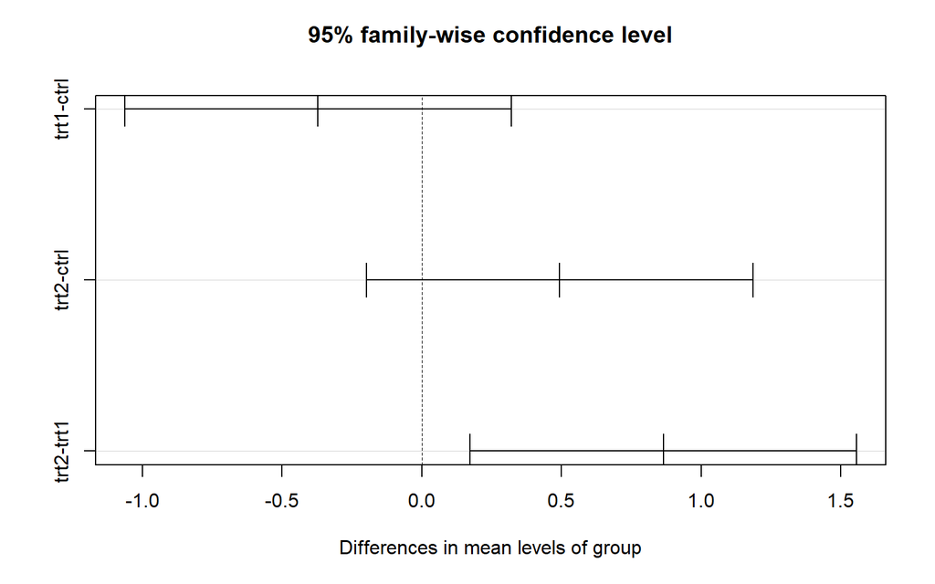

```r
plot(tukey.test)
```

**Dwuczynnikową z interakcją (ToothGrowth)**

A two-way ANOVA with interaction tests three[null hypotheses](https://www.scribbr.com/statistics/hypothesis-testing/) at the same time:

- There is no difference in group means at any level of the first independent variable.
- There is no difference in group means at any level of the second independent variable.
- The effect of one independent variable does not depend on the effect of the other independent variable (a.k.a. no interaction effect).

```r
aov_res <- aov(len ~ supp * dose, ToothGrowth)
summary(aov_res)
```

```
            Df Sum Sq Mean Sq F value   Pr(>F)
supp         1  205.4   205.4  12.317 0.000894 ***
dose         1 2224.3  2224.3 133.415  < 2e-16 ***
supp:dose    1   88.9    88.9   5.333 0.024631 *
Residuals   56  933.6    16.7
---
Signif. codes:  0 '***' 0.001 '**' 0.01 '*' 0.05 '.' 0.1 ' ' 1
```

From the ANOVA results, you can conclude the following, based on the p-values and a significance level of 0.05:

- the p-value of supp is 0.000894 (significant), which indicates that the levels of supp are associated with significant different tooth length.
- the p-value of dose is < 2e-16 (significant), which indicates that the levels of dose are associated with significant different tooth length.
- the p-value for the interaction between supp*dose is 0.02 (significant), which indicates that the relationships between dose and tooth length depends on the supp method.

# Exercise 7

7. Wykonaj test Wilcoxona dla danych sparowanych (**ChickWeight**, **Time 0 i 2** i niesparowanych (**iris**)

**a. Niesparowane:**

```r
iris_setosa <- subset(iris, Species == "setosa")
iris_versicolor <- subset(iris, Species == "versicolor")
wilcox.test(iris_setosa$Sepal.Length, iris_versicolor$Sepal.Length)
```

```
    Wilcoxon rank sum test with continuity correction

data:  iris_setosa$Sepal.Length and iris_versicolor$Sepal.Length
W = 168.5, p-value = 8.346e-14
alternative hypothesis: true location shift is not equal to 0
```

The **p-value** of the test is 8.346e-14, which is less than the significance level alpha = 0.05. We can conclude that setosa’s median Sepal Length is significantly different from versicolor’s median Sepal Length with a p-value = 8.346e-14.

**b. ChickWeight:**

```r
wilcox.test(ch_time0$weight, ch_time2$weight)
```

```
    Wilcoxon rank sum test with continuity correction

data:  ch_time0$weight and ch_time2$weight
W = 107.5, p-value = 2.176e-15
alternative hypothesis: true location shift is not equal to 0
```

The **p-value** of the test is 2.176e-15, which is less than the significance level alpha = 0.05. We can conclude that chick’s median weight in time 0 is significantly different from chick’s median weight in time 2 with a p-value = 2.176e-15.

# Exercise 8

8. Wykonaj test Kruskala-Wallisa

The Kruskal Wallis test is the non parametric alternative to the One Way [ANOVA](https://www.statisticshowto.com/probability-and-statistics/hypothesis-testing/anova/). [*Non parametric*](https://www.statisticshowto.com/probability-and-statistics/statistics-definitions/parametric-and-non-parametric-data/) means that the test doesn’t assume your data comes from a particular distribution. The H test is used when the assumptions for ANOVA aren’t met (like the [assumption of normality](https://www.statisticshowto.com/assumption-of-normality-test/)). It is sometimes called the *one-way ANOVA on ranks*, as the ranks of the data values are used in the test rather than the actual data points.

The test determines whether the [medians](https://www.statisticshowto.com/probability-and-statistics/statistics-definitions/mean-median-mode/#median) of two or more groups are different. Like most statistical tests, you calculate a [test statistic](https://www.statisticshowto.com/test-statistic/) and compare it to a distribution cut-off point. The test statistic used in this test is called the **H statistic.** The hypotheses for the test are:

- H<sub>0</sub>: population medians are equal.
- H<sub>1</sub>: population medians are not equal.

```r
kruskal.test(weight ~ group, PlantGrowth)
```

```
    Kruskal-Wallis rank sum test

data:  weight by group
Kruskal-Wallis chi-squared = 7.9882, df = 2, p-value = 0.01842
```

As the p-value is less than the significance level 0.05, we can conclude that there are significant differences between the treatment groups.

# Exercise 9

Wykonaj analizę regresji (zależność między gęstością [density] i stężeniem [conc[) – baza **DNase**, dla dowolnego runu (ELISA dla rekombinowanej DNAzy)

```r
m1 <- lm(conc ~ density, subset(DNase, Run == 1))
summary(m1)
```

```
Call:
lm(formula = conc ~ density, data = subset(DNase, Run == 1))

Residuals:
     Min       1Q   Median       3Q      Max
-2.20770 -1.13343 -0.03027  0.83960  2.66889

Coefficients:
            Estimate Std. Error t value Pr(>|t|)
(Intercept)  -1.3010     0.5878  -2.213    0.044 *
density       6.5100     0.6586   9.885 1.08e-07 ***
---
Signif. codes:  0 '***' 0.001 '**' 0.01 '*' 0.05 '.' 0.1 ' ' 1

Residual standard error: 1.532 on 14 degrees of freedom
Multiple R-squared:  0.8747,    Adjusted R-squared:  0.8657
F-statistic: 97.71 on 1 and 14 DF,  p-value: 1.078e-07
```

When run = 1, There’s a positive and statistically significant relationship between density and concentration since the estimate is positive and p-value = 1.08e-07 which is less than the significance level alpha = 0.05. Based on the estimates we can conclude that 1 unit increase of density increases concentration by 6.51 in average. The Adjusted R-squared: 0.8657 indicates that density explains aproximately 87% of the variance of the concentration, which is a good model.

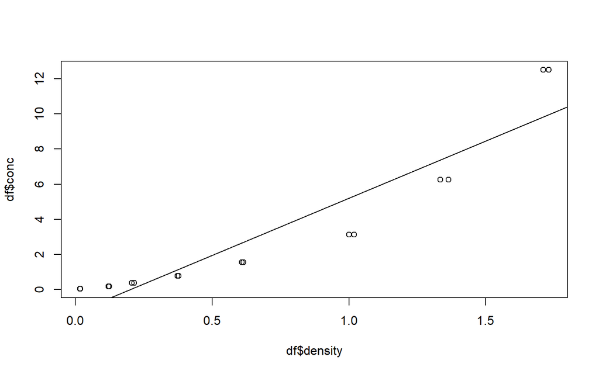

```r
df <- subset(DNase, Run == 1)
plot(df$density, df$conc)
abline(m1)
```

Based on the plot we can infer that the relationship rather than linear, would be exponential.